# Protein_aggregation_vs_subcellular_location

# Initialization

## Install all the needed libraries.

```r
#install.packages("UniprotR")
#install.packages("BiocManager")
#BiocManager::install("Biostrings")
#BiocManager::install("GenomicAlignments")
#install.packages("sjmisc")
#install.packages("hash")
#install.packages("dplyr")
#install.packages("Peptides")
#install.packages("dgof")
#install.packages("igraph")
#install.packages("ggpubr")
#install.packages("gtools")
#install.packages("groupdata2")
```

## Load the needed libraries.

```r
library(UniprotR)
library(sjmisc) # Used for str_contains
library(hash) # Used to make a dictionary
library(dplyr) # Used for aggregate (get avg tango score of protein)
library(Peptides) # Used for charge (get the charge of a peptide sequence) ETC
library(ggplot2)
library(dplyr)
library(ggrepel)
library(tidyverse)
library(igraph)
```

## Define the working directory.

```r
directory = dirname(rstudioapi::getSourceEditorContext()$path) # Place the data in a Data folder on the path of this file
setwd(directory)
```

## Load the data.

```r
source("load_data.R")
return_value = read_data() # See load_data.R
data = return_value$data
hashed_proteins = return_value$hashed_proteins
rm(return_value) # To get rid of the extra memory usage
```

## Exploratory analysis

### – Co-occurrence Matrix –

This function gives the number of proteins that are shared by different subcellular locations.

If relative = **FALSE**, the absolute number of shared proteins is displayed.

If relative = **TRUE**, the ratio of the intersection to the union of the two subcellular locations is shown multiplied by 10000.

### Interpretation:

We see that most of the proteins that are located in the nucleus are also common for the cytoplasm as a subcellular location. Cytoplasm also shares common proteins with cell membrane. Co-occurrence plot seem to be in line with the general pattern of protein locations. For example: It is most probably expected that if protein is located in the nucleus then it will also be in the cytoplasm (transcription factor).

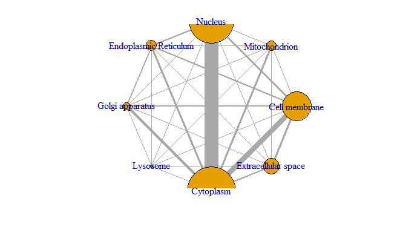

```r
source("co_occurence.R")
plot_co_occurence(relative = FALSE)
```

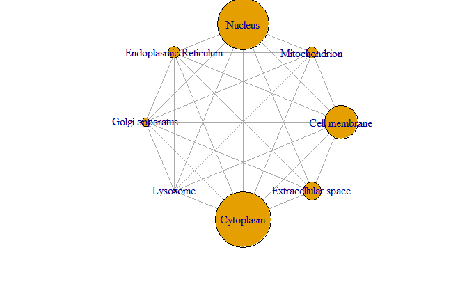

```r
plot_co_occurence(relative = TRUE)
```

# TANGO scores

```r
source("tango_scores.R")
```

## Average tango score distribution in all proteins

### Function Documentation:

**plot_average_tango_scores_complete_proteins**: Generates the violin plot for all of the proteins according to their subcellular locations. Red points demonstrate the mean value of Tango Score for all subcellular locations.

**significance_subcellular**: Following function calculates the significance in tango scores between the subcellular locations. It uses Mann-Whitney significance test to compare between two protein sample groups. As a result, returns the p-value table of pairwise subcellular locations.

**get_krustal_test_results**: For calculating the general significance of the proteins with respect to average tango scores for subcellular locations.

**get_wilcox_test_table**: Function that is used to calculate the significance between all subcellular locations for different datasets of proteins (all proteins, only proteins with APR regions) and their respective tango scores (max score, average score) and writes the result into csv file. Also generates a heatmap to demonstrate these values.

**plot_stat_significance**: Plotting the options for statistical significance for all proteins to check whether mean tango scores for each subcellular location are significant or not.

**Click here to see more info about [violin plots](https://en.wikipedia.org/wiki/Violin_plot)**

##Statistical tests and visualisation for subcellular location

### Interpretation:

Heatmap can be checked to see the significance level for the difference in the average score of different subcellular locations. All things considered, when significance is checked with respect to the mean, we see that only 3 subcellular locations are not significant according to the test.

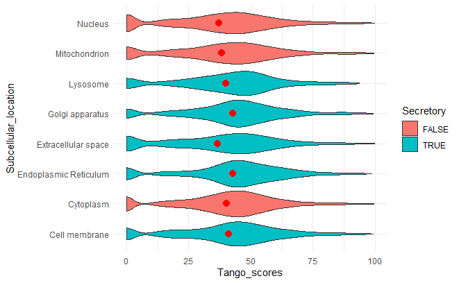

```r
plot_average_tango_scores_complete_proteins()
```

```r
significance_subcellular(tango_scores_complete_protein)
```

```
    Pairwise comparisons using Wilcoxon rank sum test with continuity correction

data:  data$Tango_scores and data$Subcellular_location

                      Cell membrane Cytoplasm Endoplasmic Reticulum Extracellular space
Cytoplasm             0.02576       -         -                     -
Endoplasmic Reticulum 0.00226       1.9e-07   -                     -
Extracellular space   3.6e-10       2.0e-07   4.4e-14               -
Golgi apparatus       0.07177       0.00061   0.37240               7.2e-10
Lysosome              0.44374       0.90547   0.01495               0.02144
Mitochondrion         0.00041       0.01855   2.3e-08               0.10577
Nucleus               < 2e-16       1.9e-13   < 2e-16               0.90050
                      Golgi apparatus Lysosome Mitochondrion
Cytoplasm             -               -        -
Endoplasmic Reticulum -               -        -
Extracellular space   -               -        -
Golgi apparatus       -               -        -
Lysosome              0.07183         -        -
Mitochondrion         1.3e-05         0.20412  -
Nucleus               1.0e-12         0.01494  0.07177

P value adjustment method: BH
```

```r
get_krustal_test_results(tango_scores_complete_protein)
```

```
    Kruskal-Wallis rank sum test

data:  Tango_scores by Subcellular_location
Kruskal-Wallis chi-squared = 183.28, df = 7, p-value < 2.2e-16
```

```
                      Cell membrane    Cytoplasm Endoplasmic Reticulum Extracellular space
Cytoplasm              2.575620e-02           NA                    NA                  NA
Endoplasmic Reticulum  2.264775e-03 1.859984e-07                    NA                  NA
Extracellular space    3.636509e-10 1.984295e-07          4.409570e-14                  NA
Golgi apparatus        7.176856e-02 6.145809e-04          3.724034e-01        7.180290e-10
Lysosome               4.437389e-01 9.054734e-01          1.494581e-02        2.143704e-02
Mitochondrion          4.068019e-04 1.855164e-02          2.288982e-08        1.057673e-01
Nucleus                2.197400e-16 1.887637e-13          2.729710e-19        9.005029e-01
                      Golgi apparatus   Lysosome Mitochondrion
Cytoplasm                          NA         NA            NA
Endoplasmic Reticulum              NA         NA            NA
Extracellular space                NA         NA            NA
Golgi apparatus                    NA         NA            NA
Lysosome                 7.182694e-02         NA            NA
Mitochondrion            1.263542e-05 0.20412381            NA
Nucleus                  1.008170e-12 0.01494069    0.07176856
```

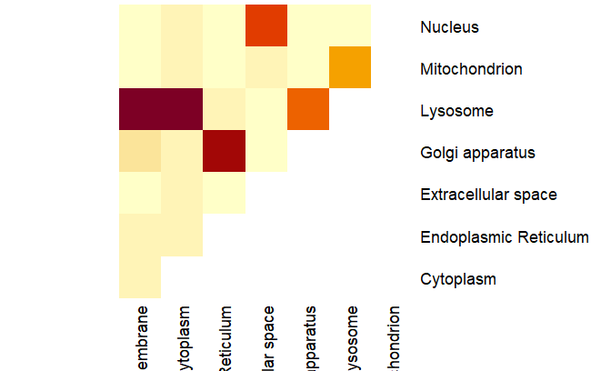

```r
get_wilcox_test_table(tango_scores_complete_protein)
```

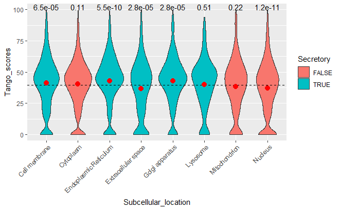

```r
plot_stat_significance(tango_scores_complete_protein)
```

##Statistical tests and visualisation on secretory vs. non-secretory

### Function Documentation:

**plot_average_tango_scores_complete_proteins_joined_secreted**: Generates the violin plot for all of the proteins according to their subcellular locations. However, this time all proteins are clustered under secretory and non-secretory groups. Red points are showing the mean value of Tango Score for these categories.

**significance secretory**: Following function calculates the significance in tango scores between the secretory and non-secretory proteins. It uses Mann-Whitney significance test to compare between two protein sample groups. As a result, returns the pairwise p-value of these 2 protein groups.

**plot_stat_significance_secretory**: Function for visualization of the Mann-Whitney test for the distributions of tango scores. Distributions are calculated using secretory and non-secretory groups for all proteins.

### Interpretation:

When proteins for different subcellular locations are clustered into 2 different categories such as secreted and non-secreted, these 2 categories are significantly different between each other.

```r
#plot_average_tango_scores_complete_proteins_joined_secreted()
significance_secretory(tango_scores_complete_protein)
```

```
    Wilcoxon rank sum test with continuity correction

data:  x and y
W = 52290101, p-value = 4.864e-11
alternative hypothesis: true location shift is not equal to 0
```

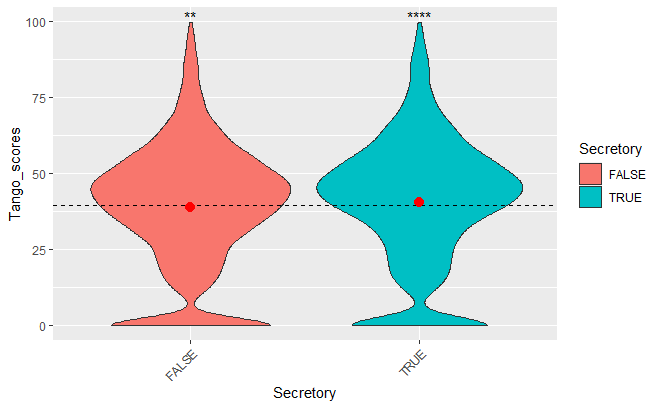

```r
plot_stat_significance_secretory(tango_scores_complete_protein)
```

## Average tango score distribution in proteins with an APR region

### Function Documentation:

**plot_average_tango_scores_APR_proteins**: Generates the violin plot for all of the proteins that have APR region according to their subcellular locations. Red points demonstrate the mean value of the Tango Score for each subcellular location.

**significance_subcellular**: Following function calculates the significance in tango scores between the subcellular locations. It uses Mann-Whitney significance test to compare between two protein sample groups. As a result, returns the p-value table of pairwise subcellular locations.

**get_krustal_test_results**: For calculating the general significance of the proteins with respect to average tango scores for subcellular locations.

**get_wilcox_test_table**: Function that is used to calculate the significance between all subcellular locations for different datasets of proteins (all proteins, only proteins with APR regions) and their respective tango scores (max score, average score) and writes the result into csv file. Also generates a heatmap to demonstrate these values.

**plot_stat_significance**: Plotting the options for statistical significance for only proteins with APR regions to check whether mean tango scores for each subcellular location are significant or not.

##Statistical tests and visualisation for subcellular location

### Interpretation:

When only proteins with APR regions are considered, significance levels are dropping significantly with respect to mean tango scores.

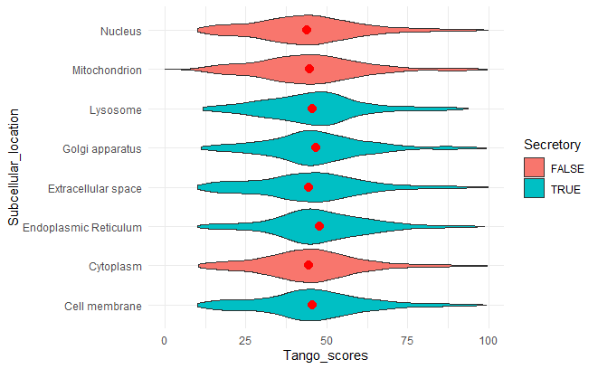

```r
plot_average_tango_scores_APR_proteins()
```

```r
significance_subcellular(tango_scores_APR_protein)
```

```
    Pairwise comparisons using Wilcoxon rank sum test with continuity correction

data:  data$Tango_scores and data$Subcellular_location

                      Cell membrane Cytoplasm Endoplasmic Reticulum Extracellular space
Cytoplasm             0.00528       -         -                     -
Endoplasmic Reticulum 0.00017       8.2e-11   -                     -
Extracellular space   0.05364       0.99311   4.7e-07               -
Golgi apparatus       0.19020       0.00098   0.08405               0.00757
Lysosome              0.99311       0.24676   0.03969               0.29378
Mitochondrion         0.08501       0.99311   1.6e-06               0.99311
Nucleus               1.0e-06       0.00896   6.2e-15               0.10212
                      Golgi apparatus Lysosome Mitochondrion
Cytoplasm             -               -        -
Endoplasmic Reticulum -               -        -
Extracellular space   -               -        -
Golgi apparatus       -               -        -
Lysosome              0.43449         -        -
Mitochondrion         0.00990         0.29378  -
Nucleus               2.6e-06         0.04664  0.16112

P value adjustment method: BH
```

```r
get_krustal_test_results(tango_scores_APR_protein)
```

```
    Kruskal-Wallis rank sum test

data:  Tango_scores by Subcellular_location
Kruskal-Wallis chi-squared = 92.981, df = 7, p-value < 2.2e-16
```

```
                      Cell membrane    Cytoplasm Endoplasmic Reticulum Extracellular space
Cytoplasm              5.283263e-03           NA                    NA                  NA
Endoplasmic Reticulum  1.653977e-04 8.187698e-11                    NA                  NA
Extracellular space    5.364303e-02 9.931086e-01          4.656846e-07                  NA
Golgi apparatus        1.902040e-01 9.757260e-04          8.405114e-02         0.007570514
Lysosome               9.931086e-01 2.467637e-01          3.969488e-02         0.293781511
Mitochondrion          8.500616e-02 9.931086e-01          1.619955e-06         0.993108598
Nucleus                1.019192e-06 8.960866e-03          6.234930e-15         0.102121418
                      Golgi apparatus   Lysosome Mitochondrion
Cytoplasm                          NA         NA            NA
Endoplasmic Reticulum              NA         NA            NA
Extracellular space                NA         NA            NA
Golgi apparatus                    NA         NA            NA
Lysosome                 4.344906e-01         NA            NA
Mitochondrion            9.899248e-03 0.29378151            NA
Nucleus                  2.565423e-06 0.04663762     0.1611161
```

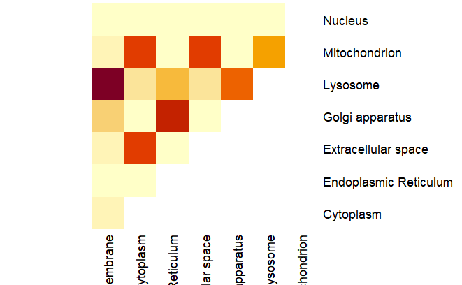

```r
get_wilcox_test_table(tango_scores_APR_protein)
```

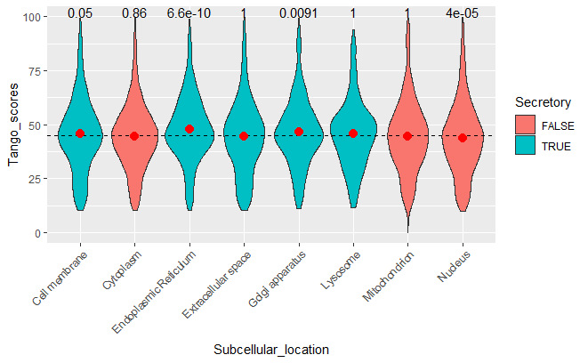

```r
plot_stat_significance(tango_scores_APR_protein)
```

##Statistical tests and visualisation on secretory vs. non-secretory

### Function Documentation:

**plot_average_tango_scores_APR_proteins_joined_secreted**: Generates the violin plot for all of the proteins with APR regions according to their subcellular locations. However, this time all APR proteins are clustered under secretory and non-secretory groups. Red points are showing the mean value of Tango Score for these categories.

**significance_secretory**: Following function calculates the significance in tango scores between the secretory and non-secretory proteins. It uses Mann-Whitney significance test to compare between two protein sample groups. As a result, returns the pairwise p-value of these 2 protein groups.

**plot_stat_significance_secretory**: Function for visualization of the Mann-Whitney test for the distributions of tango scores. Distributions are calculated using secretory and non-secretory groups for all proteins.

### Interpretation:

When proteins for different subcellular locations are clustered into 2 different categories such as secreted and non-secreted, these 2 categories are significantly different between each other in terms of mean tango scores.

```r
#plot_average_tango_scores_APR_proteins_joined_secreted()
significance_secretory(tango_scores_APR_protein)
```

```
    Wilcoxon rank sum test with continuity correction

data:  x and y
W = 40701679, p-value = 1.19e-12
alternative hypothesis: true location shift is not equal to 0
```

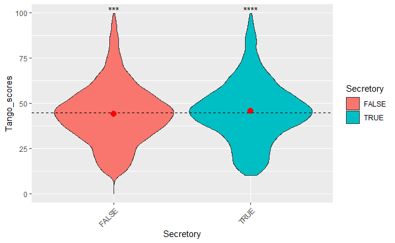

```r
plot_stat_significance_secretory(tango_scores_APR_protein)
```

## Distribution of maximal tango scores

### Statistical tests and visualisation for subcellular location

### Function Documentation:

**plot_max_tango_scores**: Generates the violin plot for max tango score of all proteins according to their subcellular locations. Red points demonstrate the mean value of the tango score for each subcellular location.

**significance_subcellular**: Following function calculates the significance in tango scores between the subcellular locations. It uses Mann-Whitney significance test to compare between two protein sample groups. As a result, returns the p-value table of pairwise subcellular locations.

**get_krustal_test_results**: For calculating the general significance of the proteins with respect to their max tango scores for subcellular locations.

**get_wilcox_test_table**: Function that is used to calculate the significance between all subcellular locations for different datasets of proteins (all proteins, only proteins with APR regions) and their respective tango scores (max score, average score) and writes the result into csv file.

**plot_stat_significance**: Plotting the options for statistical significance for all proteins to check whether max tango scores for each subcellular location are significant or not.

### Interpretation:

We see that mean value of the max tango scores for each subcellular locations. Mean values are significant for all subcellular locations except lysosome and cell membrane.

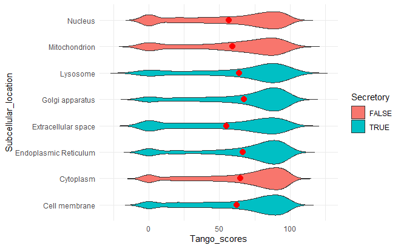

```r
plot_max_tango_scores()
```

```r
significance_subcellular(max_tango_scores)
```

```
    Pairwise comparisons using Wilcoxon rank sum test with continuity correction

data:  data$Tango_scores and data$Subcellular_location

                      Cell membrane Cytoplasm Endoplasmic Reticulum Extracellular space
Cytoplasm             0.00149       -         -                     -
Endoplasmic Reticulum 3.8e-05       0.02894   -                     -
Extracellular space   4.5e-13       < 2e-16   < 2e-16               -
Golgi apparatus       4.1e-05       0.02107   0.76258               < 2e-16
Lysosome              0.17806       0.85041   0.36495               2.6e-06
Mitochondrion         0.00079       3.9e-09   1.3e-10               0.01219
Nucleus               1.2e-13       < 2e-16   < 2e-16               0.10824
                      Golgi apparatus Lysosome Mitochondrion
Cytoplasm             -               -        -
Endoplasmic Reticulum -               -        -
Extracellular space   -               -        -
Golgi apparatus       -               -        -
Lysosome              0.27042         -        -
Mitochondrion         4.1e-10         0.00184  -
Nucleus               < 2e-16         2.3e-05  0.11445

P value adjustment method: BH
```

```r
get_krustal_test_results(max_tango_scores)
```

```
    Kruskal-Wallis rank sum test

data:  Tango_scores by Subcellular_location
Kruskal-Wallis chi-squared = 302.32, df = 7, p-value < 2.2e-16
```

```
                      Cell membrane    Cytoplasm Endoplasmic Reticulum Extracellular space
Cytoplasm              1.486903e-03           NA                    NA                  NA
Endoplasmic Reticulum  3.806143e-05 2.893690e-02                    NA                  NA
Extracellular space    4.490915e-13 5.056164e-25          1.839579e-20                  NA
Golgi apparatus        4.089278e-05 2.106611e-02          7.625810e-01        9.463701e-19
Lysosome               1.780613e-01 8.504060e-01          3.649541e-01        2.620189e-06
Mitochondrion          7.876366e-04 3.857697e-09          1.254925e-10        1.219173e-02
Nucleus                1.202308e-13 6.282169e-34          2.159765e-21        1.082378e-01
                      Golgi apparatus     Lysosome Mitochondrion
Cytoplasm                          NA           NA            NA
Endoplasmic Reticulum              NA           NA            NA
Extracellular space                NA           NA            NA
Golgi apparatus                    NA           NA            NA
Lysosome                 2.704150e-01           NA            NA
Mitochondrion            4.148549e-10 1.840570e-03            NA
Nucleus                  9.463701e-19 2.337466e-05     0.1144483
```

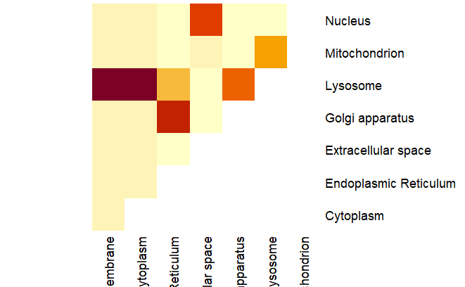

```r
get_wilcox_test_table(max_tango_scores)
```

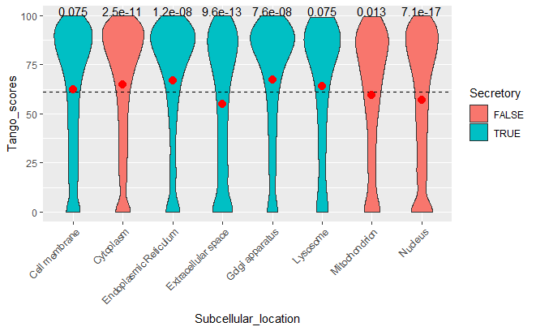

```r
plot_stat_significance(max_tango_scores)
```

##Statistical tests and visualisation on secretory vs. non-secretory

### Function Documentation:

**plot_max_tango_scores_complete_proteins_joined_secreted**: Generates the violin plot for max tango score of all of the proteins according to their subcellular locations. However, this time all proteins are clustered under secretory and non-secretory groups. Red points are showing the mean value of Tango Score for these categories.

**significance secretory**: Following function calculates the significance in tango scores between the secretory and non-secretory proteins. It uses Mann-Whitney significance test to compare between two protein sample groups. As a result, returns the pairwise p-value of these 2 protein groups.

**plot_stat_significance_secretory**: Function for visualization of the Mann-Whitney test for the distributions of max tango scores. Distributions are calculated using secretory and non-secretory protein groups. All proteins are included to the calculation.

### Interpretation:

When proteins in different subcellular locations are clustered, mean of the max tango scores for non-secretory proteins are not deemed as significant.

```r
# Are we going to add the plot here for secretory vs non-secretory
#plot_max_tango_scores_complete_proteins_joined_secreted() No need to use
significance_secretory(max_tango_scores)
```

```
    Wilcoxon rank sum test with continuity correction

data:  x and y
W = 50813986, p-value = 0.002927
alternative hypothesis: true location shift is not equal to 0
```

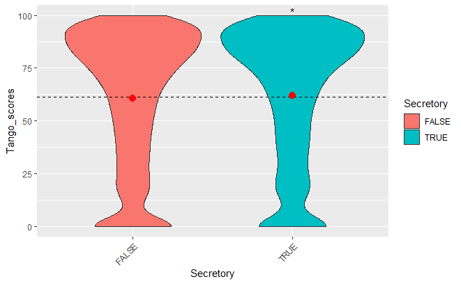

```r
plot_stat_significance_secretory(max_tango_scores)
```

## Distribution of number of APR regions per protein normalized for protein length

### Statistical tests and visualisation for subcellular location

### Function Documentation:

**significance_subcellular_nbAPR**: Following function calculates the significance in tango scores between the subcellular locations. It uses Mann-Whitney significance test to compare between two protein sample groups. As a result, returns the p-value table of pairwise subcellular locations.

**get_krustal_test_results_nbAPR**: For calculating the general significance of the proteins with respect to their normalized number of APR regions for subcellular locations.

**get_wilcox_test_table_nbAPR**: Function that is used to calculate the significance between all subcellular locations for different datasets of proteins (all proteins, only proteins with APR regions) and their respective tango scores (max score, average score) and writes the result into csv file.

**plot_stat_significance_nbAPR**: Plotting the options for statistical significance for all proteins to check whether normalized number of APR regions for each subcellular location are significant or not.

### Interpretation:

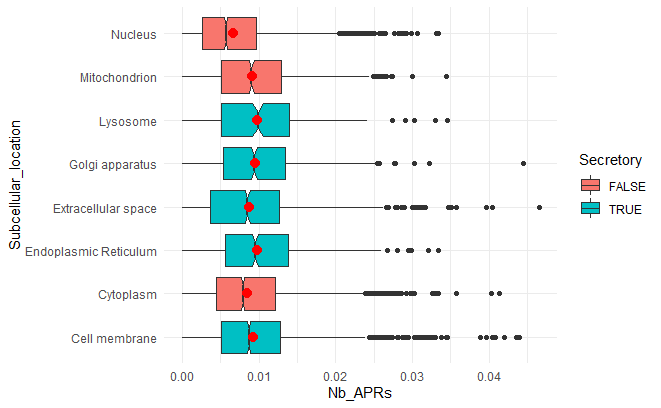

```r
plot_normalized_number_APR_regions()
```

```r
significance_subcellular_nbAPR(normalized_number_APR_regions)
```

```
    Pairwise comparisons using Wilcoxon rank sum test with continuity correction

data:  data$Nb_APRs and data$Subcellular_location

                      Cell membrane Cytoplasm Endoplasmic Reticulum Extracellular space
Cytoplasm             1.2e-07       -         -                     -
Endoplasmic Reticulum 0.0011        9.1e-13   -                     -
Extracellular space   0.0016        0.7300    2.5e-07               -
Golgi apparatus       0.0467        8.6e-08   0.4511                8.0e-05
Lysosome              0.0580        8.0e-05   0.9784                0.0016
Mitochondrion         0.5123        2.9e-05   0.0323                0.0060
Nucleus               < 2e-16       < 2e-16   < 2e-16               < 2e-16
                      Golgi apparatus Lysosome Mitochondrion
Cytoplasm             -               -        -
Endoplasmic Reticulum -               -        -
Extracellular space   -               -        -
Golgi apparatus       -               -        -
Lysosome              0.5965          -        -
Mitochondrion         0.2472          0.1471   -
Nucleus               < 2e-16         < 2e-16  < 2e-16

P value adjustment method: BH
```

```r
get_krustal_test_results_nbAPR(normalized_number_APR_regions)
```

```
    Kruskal-Wallis rank sum test

data:  Nb_APRs by Subcellular_location
Kruskal-Wallis chi-squared = 798.38, df = 7, p-value < 2.2e-16
```

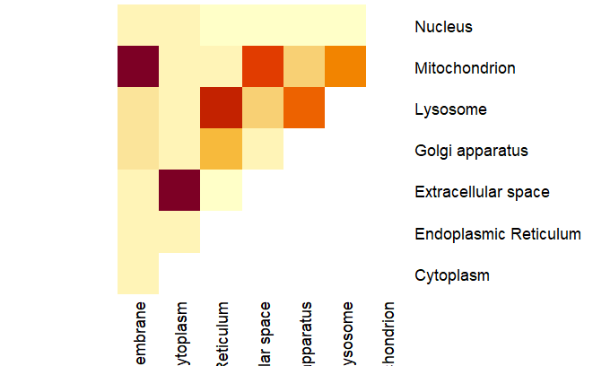

```r
get_wilcox_test_table_nbAPR(normalized_number_APR_regions)
```

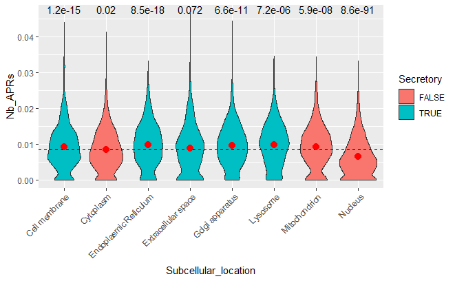

```r
plot_stat_significance_nbAPR(normalized_number_APR_regions)
```

## Statistical tests and visualisation on secretory vs. non-secretory

### Function Documentation:

**significance_secretory_nbAPR**: Following function calculates the significance in tango scores between the secretory and non-secretory proteins. It uses Mann-Whitney significance test to compare between two protein sample groups. As a result, returns the pairwise p-value of these 2 protein groups.

**plot_stat_significance_nbAPR_secretory**: Function for visualization of the Mann-Whitney test for the distributions of bumber of normalized APR regions. Distributions are calculated using secretory and non-secretory protein groups. All proteins are included in this calculation.

### Interpretation:

Again, both secretory and non-secretory groups of proteins are significant in terms of mean value of normalized APR regions. Important thing to notice in here is the fact that secretory proteins are showing a higher normalized APR region value compared to non-secretory group of proteins.

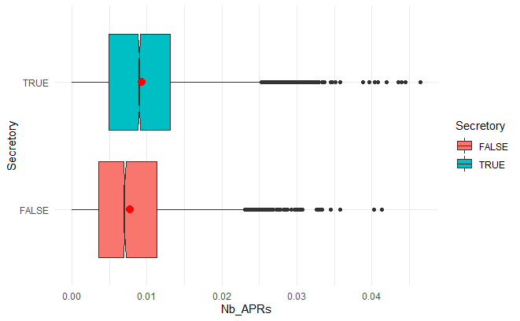

```r
plot_normalized_number_APR_regions_joined_secreted()
```

```r
significance_secretory_nbAPR(normalized_number_APR_regions)
```

```
    Wilcoxon rank sum test with continuity correction

data:  x and y
W = 56868553, p-value < 2.2e-16
alternative hypothesis: true location shift is not equal to 0
```

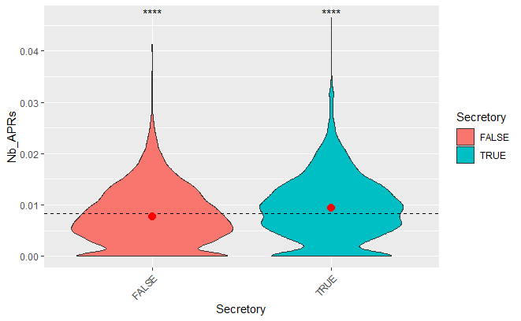

```r
plot_stat_significance_nbAPR_secretory(normalized_number_APR_regions)
```

# Peptide charges

This part of the analysis is not considered. Still, explanation of the function is as follows:

**classify_subsets**: Get the subset of the APR proteins depending on the definition of the residue (GK, distal region, flanking region, APR region). We define different subsets to filter the data depending on the residue category.

```r
source("charges.R")
classify_subsets()
```

Defining the variables depending on the filtration method of the whole data.

```r
# TODO: make plots showing the differences between APR, GK and FR based on charges
# TODO: see if differences when split into subcellular locations

# protein_sequences_APR_peptides = get_charge(APR_peptides)
# protein_sequences_GK_peptides = get_charge(GK_peptides)
# protein_sequences_FR_peptides = get_charge(FR_peptides)
```

If this analysis is not done, delete the following variables to speed up the memory

```r
rm(APR_peptides)
rm(GK_peptides)
rm(FR_peptides)
```

# Residues inside Gatekeeper and flanking regions analysis

positive charged aas (“positive”) –> R,H,K  
negative charged aas (“negative”) –> D,E  
uncharged aas (“uncharged”) –> S,T,N,Q  
special cases aas (“special”) –> C,G,P,A  
hydrophobic aas (“hydrophobic”) –> V,I,L,M,F,Y,W

**Specific residues of interest**

Lysine (Lys) –> K  
Arginine (Arg) –> R  
Aspartic acid (Asp) –> D  
Glutamic acid (Glu) –> E

```r
source("gatekeeper.R")
```

## Only for the GK regions

**analyse_gate_keeper_regions**: General analysis of all proteins for only GK regions

```r
GK_analysis = analyse_gate_keeper_regions()
```

### PERCENTAGE OF ALL RESIDUES FOR ALL OF THE GK REGIONS IN ALL PROTEINS

**barplot_percentage_of_all_residues**: Function to plot the percentage of all residues in the GK regions of all proteins.

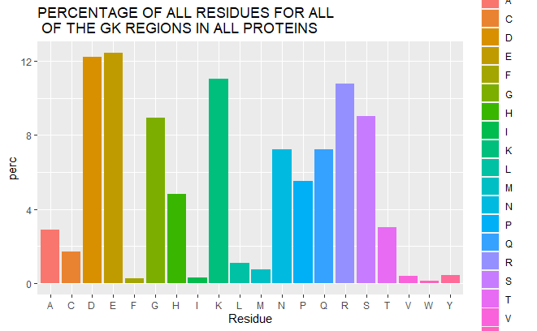

```r
barplot_percentage_of_all_residues(GK_analysis$cts_gk, "GK REGIONS")
```

### PERCENTAGE OF ALL RESIDUES FOR ALL OF THE GK + FL REGIONS IN ALL PROTEINS

**barplot_percentage_of_all_residues**: Plots the percentage of all 20 residues for every protein. Considers the residues in the GK and flanking regions.

### Interpretation:

We have more abundance of specific residues when we only consider the percentage of the amino acids in the GK regions. However, when percentages are calculated for residues that are also in the flanking regions, we see that higher percentage of some residues are dropping to the average level instead of increasing or remaining still. This indicates that GK regions indeed have some preference for specific residues. These residues are mostly the charged amino acids.

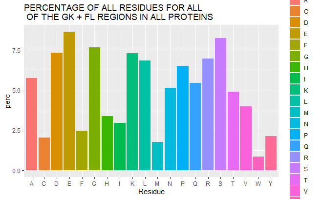

```r
barplot_percentage_of_all_residues(GK_analysis$cts_gk_fl, "GK + FL REGIONS")
```

### PERCENTAGE OF ALL GROUPS OF RESIDUES FOR ALL THE GK REGIONS IN ALL PROTEINS

**barplot_percentage_of_all_residues**: Occurrence of the residues in GK region depending on the category of the amino acid.

### Intepretation:

We see very little preference for hydrophobic residues since the whole purpose of GK regions are assumed to be preventing the aggregation of proteins with other hydrophobic regions.

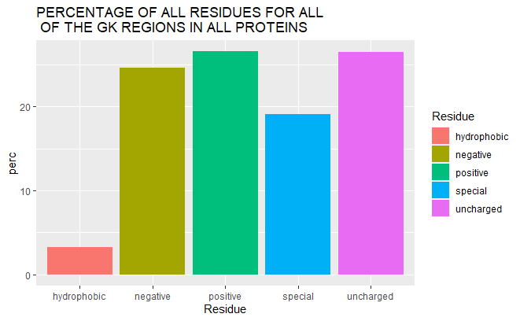

```r
barplot_percentage_of_all_residues(GK_analysis$cts_gk_groups, "GK REGIONS")
```

### PERCENTAGE OF ALL GROUPS OF RESIDUES FOR ALL THE GK + FL REGIONS IN ALL PROTEINS

**barplot_percentage_of_all_residues**: Occurrence of the residues in GK + FL region depending on the category of the amino acid.

### Interpretation:

When flanking regions are included, percentage of these groups of residues gets closer to average probability which is 20%

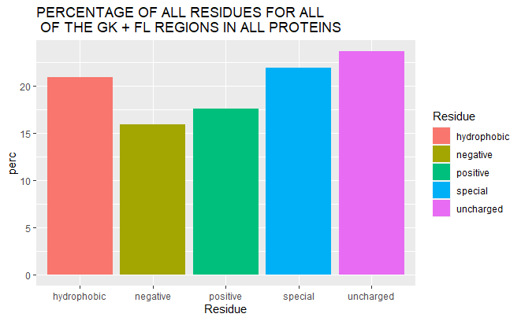

```r
barplot_percentage_of_all_residues(GK_analysis$cts_gk_fl_groups, "GK + FL REGIONS")
```

## Interested residues

### PERCENTAGE OF INTERESTED RESIDUES FOR ALL OF THE GK REGIONS IN ALL PROTEINS

Lysine (Lys) –> K  
Arginine (Arg) –> R  
Aspartic acid (Asp) –> D  
Glutamic acid (Glu) –> E  
Serine (Ser) –> S  
Proline (Pro) –> P

**analyse_interested_gate_keeper_regions**: Obtain the percentage of the interested residues in GK regions or GK + flanking regions.

```r
GK_analysis_interested_aa = analyse_interested_gate_keeper_regions(GK_analysis)
```

**barplot_percentage_of_interested_residues**: Plotting the percentage of interested residues in the GK region of all proteins.

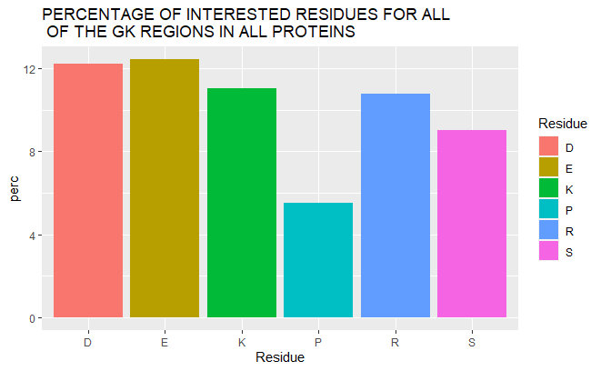

```r
barplot_percentage_of_interested_residues(GK_analysis_interested_aa$cts_interest_gk, "GK REGIONS")
```

### PERCENTAGE OF INTERESTED RESIDUES FOR ALL OF THE GK + FL REGIONS IN ALL PROTEINS

**barplot_percentage_of_interested_residues**: Plotting the percentage of interested residues in the GK + flanking region of all proteins.

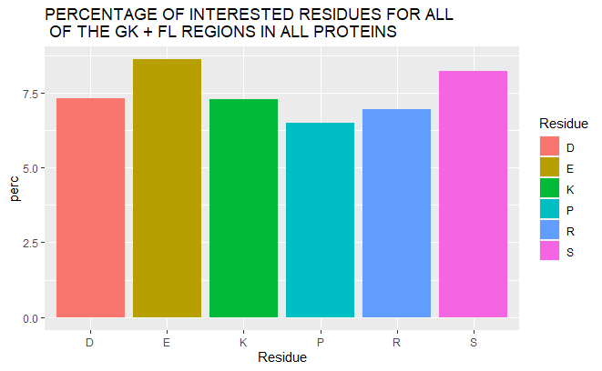

```r
barplot_percentage_of_interested_residues(GK_analysis_interested_aa$cts_interest_gk_fl, "GK + FL REGIONS")
```

### PERCENTAGE OF INTERESTED RESIDUES FOR ALL OF THE GK SIDES

**analyse_gate_keeper_residues**: Obtain the side information for the interested residues in the GK regions.

```r
GK_analysis_GK_residues = analyse_gate_keeper_residues(GK_analysis$cts_gk_side)
side_string = "GK"
```

**pie_plot_percentage_of_specific_residue**: Plotting the side information for each interested amino acid in GK regions.

### Interpretation:

Slight preference for Ser on the right GK region and also huge preference for the Pro for the left side of the GK regions.

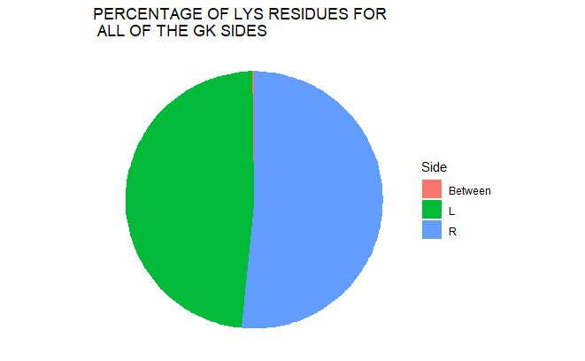

```r
pie_plot_percentage_of_specific_residue(GK_analysis_GK_residues$lys_ct, "LYS", side_string)
```

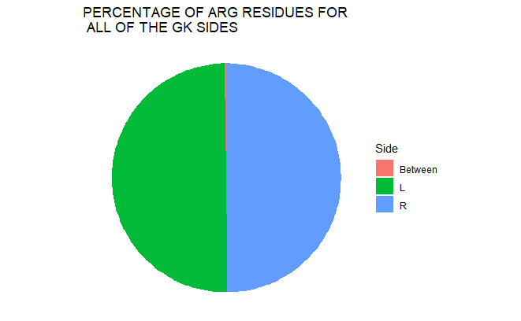

```r
pie_plot_percentage_of_specific_residue(GK_analysis_GK_residues$arg_ct, "ARG", side_string)
```

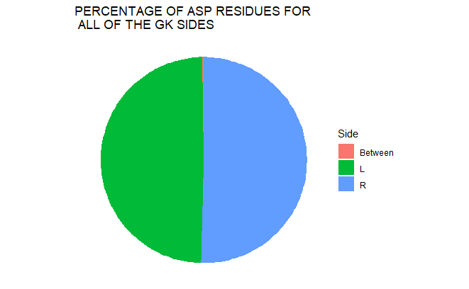

```r
pie_plot_percentage_of_specific_residue(GK_analysis_GK_residues$asp_ct, "ASP", side_string)
```

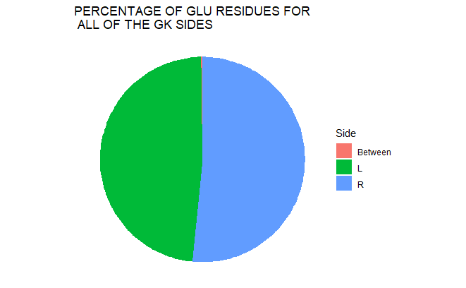

```r
pie_plot_percentage_of_specific_residue(GK_analysis_GK_residues$glu_ct, "GLU", side_string)
```

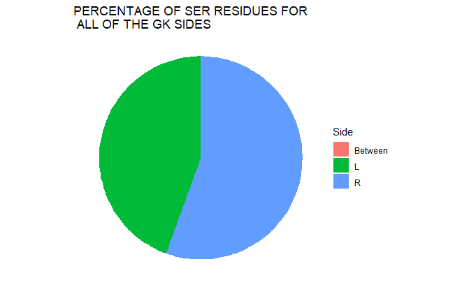

```r
pie_plot_percentage_of_specific_residue(GK_analysis_GK_residues$ser_ct, "SER", side_string)
```

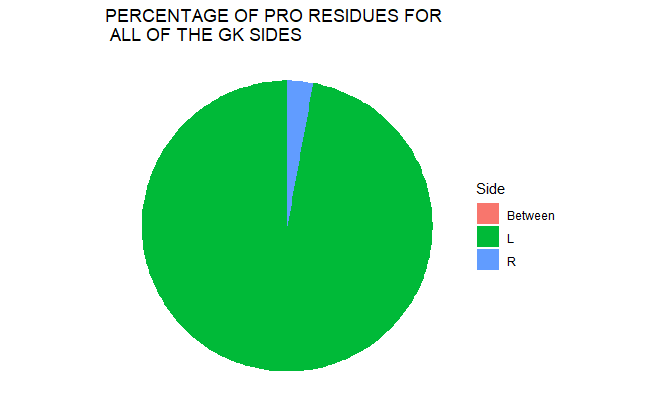

```r
pie_plot_percentage_of_specific_residue(GK_analysis_GK_residues$pro_ct, "PRO", side_string)
```

### PERCENTAGE OF INTERESTED RESIDUES FOR ALL OF THE GK + FL SIDES

**analyse_gate_keeper_residues**: Obtain the side information for the interested residues in the GK + flanking regions.

```r
GK_analysis_GK_and_FL_residues = analyse_gate_keeper_residues(GK_analysis$cts_gk_fl_side)
side_string = "GK + FL"
```

**pie_plot_percentage_of_specific_residue**: Plotting the side information for each interested amino acid in GK + flanking regions.